# ArticlePopularityPrediction - ML Project

Vansh Chandwaney

2023-10-24

# Case Objective and Data Description

The objective of this report is to predict the popularity of articles posted on Mashable, a renowned news website and entertainment company, by analyzing different predictive models. The focus is on automating the selection process of articles based on their potential to generate high shares, which directly impacts revenue.

# Loading necessary libraries

```r
library(dplyr)
```

```r
library(ggplot2)
library(corrplot)
library(caret)
library(tidyverse)
library(rpart.plot)
library(xgboost)
library(randomForest)
library(e1071)
library(pROC)
```

# Loading the dataset

```r
mashable_data <- read.csv("OnlineNewsPopularity.csv")
View(mashable_data)
```

# Exploratory Data Analysis (EDA)

## Summarising the data and checking for missing values

```r
summary(mashable_data)
```

```
##      url              timedelta     n_tokens_title n_tokens_content
##  Length:39644       Min.   :  8.0   Min.   : 2.0   Min.   :   0.0
##  Class :character   1st Qu.:164.0   1st Qu.: 9.0   1st Qu.: 246.0
##  Mode  :character   Median :339.0   Median :10.0   Median : 409.0
##                     Mean   :354.5   Mean   :10.4   Mean   : 546.5
##                     3rd Qu.:542.0   3rd Qu.:12.0   3rd Qu.: 716.0
##                     Max.   :731.0   Max.   :23.0   Max.   :8474.0
##  n_unique_tokens    n_non_stop_words    n_non_stop_unique_tokens
##  Min.   :  0.0000   Min.   :   0.0000   Min.   :  0.0000
##  1st Qu.:  0.4709   1st Qu.:   1.0000   1st Qu.:  0.6257
##  Median :  0.5392   Median :   1.0000   Median :  0.6905
##  Mean   :  0.5482   Mean   :   0.9965   Mean   :  0.6892
##  3rd Qu.:  0.6087   3rd Qu.:   1.0000   3rd Qu.:  0.7546
##  Max.   :701.0000   Max.   :1042.0000   Max.   :650.0000
##    num_hrefs      num_self_hrefs       num_imgs         num_videos
##  Min.   :  0.00   Min.   :  0.000   Min.   :  0.000   Min.   : 0.00
##  1st Qu.:  4.00   1st Qu.:  1.000   1st Qu.:  1.000   1st Qu.: 0.00
##  Median :  8.00   Median :  3.000   Median :  1.000   Median : 0.00
##  Mean   : 10.88   Mean   :  3.294   Mean   :  4.544   Mean   : 1.25
##  3rd Qu.: 14.00   3rd Qu.:  4.000   3rd Qu.:  4.000   3rd Qu.: 1.00
##  Max.   :304.00   Max.   :116.000   Max.   :128.000   Max.   :91.00
##  average_token_length  num_keywords    data_channel_is_lifestyle
##  Min.   :0.000        Min.   : 1.000   Min.   :0.00000
##  1st Qu.:4.478        1st Qu.: 6.000   1st Qu.:0.00000
##  Median :4.664        Median : 7.000   Median :0.00000
##  Mean   :4.548        Mean   : 7.224   Mean   :0.05295
##  3rd Qu.:4.855        3rd Qu.: 9.000   3rd Qu.:0.00000
##  Max.   :8.042        Max.   :10.000   Max.   :1.00000
##  data_channel_is_entertainment data_channel_is_bus data_channel_is_socmed
##  Min.   :0.000                 Min.   :0.0000      Min.   :0.0000
##  1st Qu.:0.000                 1st Qu.:0.0000      1st Qu.:0.0000
##  Median :0.000                 Median :0.0000      Median :0.0000
##  Mean   :0.178                 Mean   :0.1579      Mean   :0.0586
##  3rd Qu.:0.000                 3rd Qu.:0.0000      3rd Qu.:0.0000
##  Max.   :1.000                 Max.   :1.0000      Max.   :1.0000
##  data_channel_is_tech data_channel_is_world   kw_min_min       kw_max_min
##  Min.   :0.0000       Min.   :0.0000        Min.   : -1.00   Min.   :     0
##  1st Qu.:0.0000       1st Qu.:0.0000        1st Qu.: -1.00   1st Qu.:   445
##  Median :0.0000       Median :0.0000        Median : -1.00   Median :   660
##  Mean   :0.1853       Mean   :0.2126        Mean   : 26.11   Mean   :  1154
```

[output cut: 71 more lines]

```
##  Max.   : 0.0000       Max.   : 0.0000       Max.   : 0.0000
##  title_subjectivity title_sentiment_polarity abs_title_subjectivity
##  Min.   :0.0000     Min.   :-1.00000         Min.   :0.0000
##  1st Qu.:0.0000     1st Qu.: 0.00000         1st Qu.:0.1667
##  Median :0.1500     Median : 0.00000         Median :0.5000
##  Mean   :0.2824     Mean   : 0.07143         Mean   :0.3418
##  3rd Qu.:0.5000     3rd Qu.: 0.15000         3rd Qu.:0.5000
##  Max.   :1.0000     Max.   : 1.00000         Max.   :0.5000
##  abs_title_sentiment_polarity     shares
##  Min.   :0.0000               Min.   :     1
##  1st Qu.:0.0000               1st Qu.:   946
##  Median :0.0000               Median :  1400
##  Mean   :0.1561               Mean   :  3395
##  3rd Qu.:0.2500               3rd Qu.:  2800
##  Max.   :1.0000               Max.   :843300
```

```r
sum(is.na(mashable_data))
```

```
## [1] 0
```

## Checking data types of each column

```r
column_data_types <- sapply(mashable_data, class)
column_data_types
```

```
##                           url                     timedelta
##                   "character"                     "integer"
##                n_tokens_title              n_tokens_content
##                     "integer"                     "integer"
##               n_unique_tokens              n_non_stop_words
##                     "numeric"                     "numeric"
##      n_non_stop_unique_tokens                     num_hrefs
##                     "numeric"                     "integer"
##                num_self_hrefs                      num_imgs
##                     "integer"                     "integer"
##                    num_videos          average_token_length
##                     "integer"                     "numeric"
##                  num_keywords     data_channel_is_lifestyle
##                     "integer"                     "integer"
## data_channel_is_entertainment           data_channel_is_bus
##                     "integer"                     "integer"
##        data_channel_is_socmed          data_channel_is_tech
##                     "integer"                     "integer"
##         data_channel_is_world                    kw_min_min
##                     "integer"                     "integer"
##                    kw_max_min                    kw_avg_min
##                     "numeric"                     "numeric"
##                    kw_min_max                    kw_max_max
##                     "integer"                     "integer"
##                    kw_avg_max                    kw_min_avg
##                     "numeric"                     "numeric"
##                    kw_max_avg                    kw_avg_avg
##                     "numeric"                     "numeric"
##     self_reference_min_shares     self_reference_max_shares
##                     "numeric"                     "numeric"
##    self_reference_avg_sharess             weekday_is_monday
##                     "numeric"                     "integer"
##            weekday_is_tuesday          weekday_is_wednesday
##                     "integer"                     "integer"
##           weekday_is_thursday             weekday_is_friday
##                     "integer"                     "integer"
##           weekday_is_saturday             weekday_is_sunday
##                     "integer"                     "integer"
##                    is_weekend                        LDA_00
##                     "integer"                     "numeric"
##                        LDA_01                        LDA_02
##                     "numeric"                     "numeric"
##                        LDA_03                        LDA_04
##                     "numeric"                     "numeric"
##           global_subjectivity     global_sentiment_polarity
##                     "numeric"                     "numeric"
##    global_rate_positive_words    global_rate_negative_words
##                     "numeric"                     "numeric"
##           rate_positive_words           rate_negative_words
##                     "numeric"                     "numeric"
##         avg_positive_polarity         min_positive_polarity
##                     "numeric"                     "numeric"
##         max_positive_polarity         avg_negative_polarity
##                     "numeric"                     "numeric"
##         min_negative_polarity         max_negative_polarity
##                     "numeric"                     "numeric"
##            title_subjectivity      title_sentiment_polarity
##                     "numeric"                     "numeric"
##        abs_title_subjectivity  abs_title_sentiment_polarity
##                     "numeric"                     "numeric"
##                        shares
##                     "integer"
```

## Creating a histogram of Article Shares

This would help visually visually illustrate the distribution of article shares, providing insights into the overall engagement levels of the content posted on Mashable.

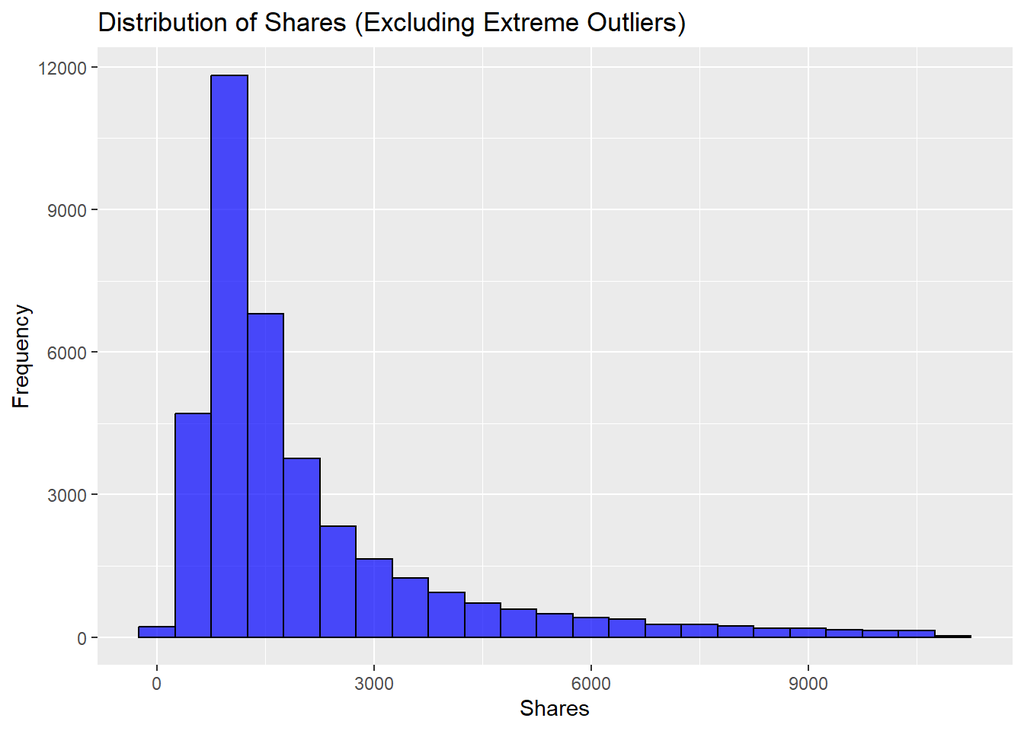

```r
# Define the 95th percentile threshold
threshold <- quantile(mashable_data$shares, 0.95)

# Filter the dataset to exclude the top 5% extreme outliers
filtered_data <- mashable_data %>% filter(shares <= threshold)

# Histogram of shares excluding extreme outliers
ggplot(filtered_data, aes(x = shares)) +
  geom_histogram(binwidth = 500, fill = "blue", color = "black", alpha = 0.7) +
  labs(title = "Distribution of Shares (Excluding Extreme Outliers)", x = "Shares", y = "Frequency")
```

## Changing data types of dummy variables to “factor”

```r
mashable_data$weekday_is_monday <- as.factor(mashable_data$weekday_is_monday)
mashable_data$weekday_is_tuesday <- as.factor(mashable_data$weekday_is_tuesday)
mashable_data$weekday_is_wednesday <- as.factor(mashable_data$weekday_is_wednesday)
mashable_data$weekday_is_thursday <- as.factor(mashable_data$weekday_is_thursday)
mashable_data$weekday_is_friday <- as.factor(mashable_data$weekday_is_friday)
mashable_data$weekday_is_saturday <- as.factor(mashable_data$weekday_is_saturday)
mashable_data$weekday_is_sunday <- as.factor(mashable_data$weekday_is_sunday)
mashable_data$is_weekend <- as.factor(mashable_data$is_weekend)
mashable_data$data_channel_is_bus <- as.factor(mashable_data$data_channel_is_bus)
mashable_data$data_channel_is_lifestyle <- as.factor(mashable_data$data_channel_is_lifestyle)
mashable_data$data_channel_is_entertainment <- as.factor(mashable_data$data_channel_is_entertainment)
mashable_data$data_channel_is_socmed <- as.factor(mashable_data$data_channel_is_socmed)
mashable_data$data_channel_is_tech <- as.factor(mashable_data$data_channel_is_tech)
mashable_data$data_channel_is_world <- as.factor(mashable_data$data_channel_is_world)
```

## Visualizing average shares by day of the week

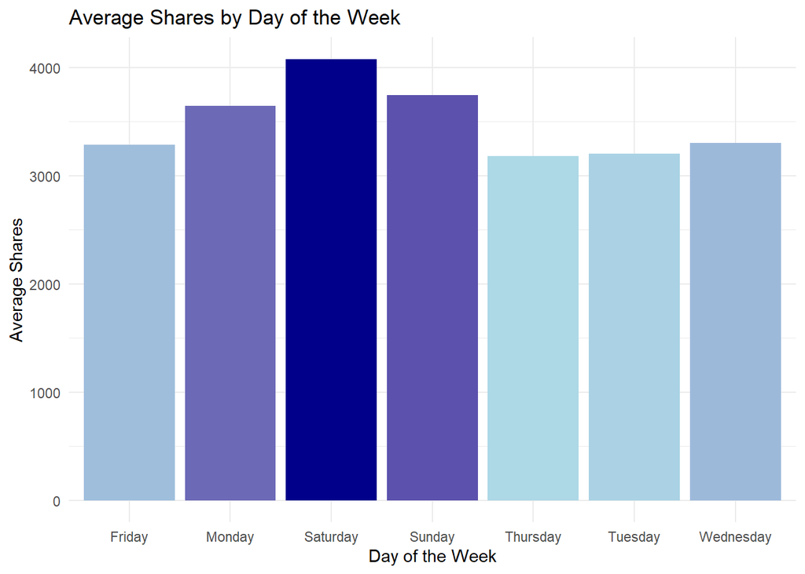

```r
# Calculate average shares by day of the week
avg_shares_by_day <- data.frame(
  weekday = c("Monday", "Tuesday", "Wednesday", "Thursday", "Friday", "Saturday", "Sunday"),
  avg_shares = c(
    mean(mashable_data$shares[mashable_data$weekday_is_monday == 1], na.rm = TRUE),
    mean(mashable_data$shares[mashable_data$weekday_is_tuesday == 1], na.rm = TRUE),
    mean(mashable_data$shares[mashable_data$weekday_is_wednesday == 1], na.rm = TRUE),
    mean(mashable_data$shares[mashable_data$weekday_is_thursday == 1], na.rm = TRUE),
    mean(mashable_data$shares[mashable_data$weekday_is_friday == 1], na.rm = TRUE),
    mean(mashable_data$shares[mashable_data$weekday_is_saturday == 1], na.rm = TRUE),
    mean(mashable_data$shares[mashable_data$weekday_is_sunday == 1], na.rm = TRUE)
  )
)

# Bar plot of average shares by day of the week with gradient colors based on size
ggplot(avg_shares_by_day, aes(x = weekday, y = avg_shares, fill = avg_shares)) +
  geom_bar(stat = "identity") +
  scale_fill_gradient(low = "lightblue", high = "darkblue") +
  labs(title = "Average Shares by Day of the Week", x = "Day of the Week", y = "Average Shares") +
  theme_minimal() +
  theme(legend.position = "none")
```

The visualization above presents the average article shares by day of the week. The highest shares were on Saturday, Sunday and Monday, and the rest of the days had negligible differences.

## Visualizing average shares by data channel

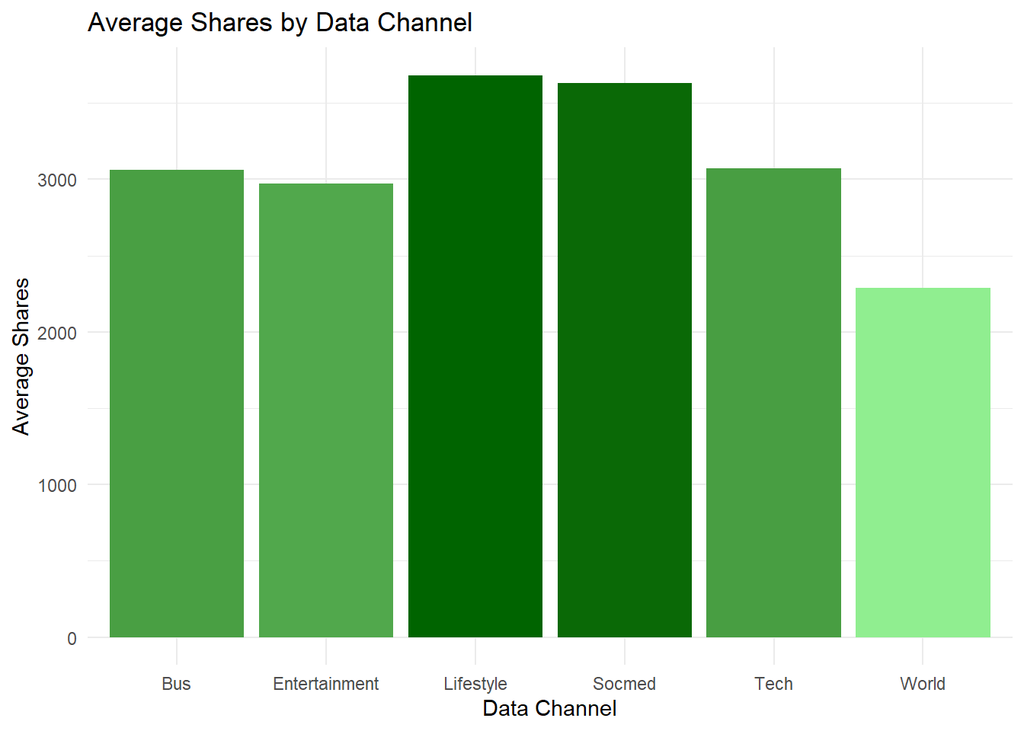

```r
# Calculate average shares by data channel
avg_shares_by_channel <- data.frame(
  data_channel = c("Bus", "Lifestyle", "Entertainment", "Socmed", "Tech", "World"),
  avg_shares = c(
    mean(mashable_data$shares[mashable_data$data_channel_is_bus == 1], na.rm = TRUE),
    mean(mashable_data$shares[mashable_data$data_channel_is_lifestyle == 1], na.rm = TRUE),
    mean(mashable_data$shares[mashable_data$data_channel_is_entertainment == 1], na.rm = TRUE),
    mean(mashable_data$shares[mashable_data$data_channel_is_socmed == 1], na.rm = TRUE),
    mean(mashable_data$shares[mashable_data$data_channel_is_tech == 1], na.rm = TRUE),
    mean(mashable_data$shares[mashable_data$data_channel_is_world == 1], na.rm = TRUE)
  )
)

# Bar plot of average shares by data channel with gradient colors based on size
ggplot(avg_shares_by_channel, aes(x = data_channel, y = avg_shares, fill = avg_shares)) +
  geom_bar(stat = "identity") +
  scale_fill_gradient(low = "lightgreen", high = "darkgreen") +
  labs(title = "Average Shares by Data Channel", x = "Data Channel", y = "Average Shares") +
  theme_minimal() +
  theme(legend.position = "none")
```

# 2. Data Pre-Processing

## Removing columns “timedelta” and “url”

```r
# This is because they do not contribute to predicting shares
library(dplyr)
mashable_data <- mashable_data %>%
  select(-timedelta, -url)
```

## Removing features from the dataset based on knowledge of the digital media industry

```r
mashable_data <- mashable_data %>%
  select(-average_token_length, -kw_min_min, -kw_max_min, -kw_min_max, -kw_max_max, -min_positive_polarity, -max_positive_polarity, -min_negative_polarity, -max_negative_polarity, -is_weekend, -self_reference_min_shares, -self_reference_max_shares)
```

## Splitting data into test and train sets

```r
dataset_split <- sample(c(TRUE, FALSE), nrow(mashable_data), replace=TRUE, prob=c(0.75,0.25))
train <- mashable_data[dataset_split, ]
test <- mashable_data[!dataset_split, ]
```

# Developing Predictive Models

## Performing linear regression

```r
linear_reg_model <- lm(shares ~ ., data = train)
summary(linear_reg_model)
```

```
##
## Call:
## lm(formula = shares ~ ., data = train)
##
## Residuals:
##    Min     1Q Median     3Q    Max
## -37937  -2302  -1241    -92 684256
##
## Coefficients: (1 not defined because of singularities)
##                                  Estimate Std. Error t value Pr(>|t|)
## (Intercept)                     3.181e+06  7.050e+06   0.451 0.651857
## n_tokens_title                  9.857e+01  3.326e+01   2.964 0.003041 **
## n_tokens_content                7.997e-01  2.517e-01   3.178 0.001487 **
## n_unique_tokens                 4.214e+03  2.008e+03   2.099 0.035839 *
## n_non_stop_words               -4.692e+03  6.813e+03  -0.689 0.491069
## n_non_stop_unique_tokens       -1.914e+03  1.766e+03  -1.084 0.278514
## num_hrefs                       1.960e+01  7.513e+00   2.609 0.009078 **
## num_self_hrefs                 -5.420e+01  2.022e+01  -2.681 0.007343 **
## num_imgs                        3.149e+00  1.041e+01   0.303 0.762221
## num_videos                      6.278e+00  1.820e+01   0.345 0.730193
## num_keywords                    6.742e+01  4.170e+01   1.617 0.105923
## data_channel_is_lifestyle1     -1.248e+03  4.600e+02  -2.714 0.006660 **
## data_channel_is_entertainment1 -1.253e+03  2.894e+02  -4.330 1.50e-05 ***
## data_channel_is_bus1           -8.341e+02  4.471e+02  -1.866 0.062089 .
## data_channel_is_socmed1        -8.264e+02  4.310e+02  -1.917 0.055196 .
## data_channel_is_tech1          -5.612e+02  4.315e+02  -1.301 0.193421
## data_channel_is_world1         -6.215e+02  4.336e+02  -1.433 0.151750
## kw_avg_min                      1.931e-01  1.332e-01   1.449 0.147319
## kw_avg_max                     -2.867e-03  7.169e-04  -3.999 6.38e-05 ***
## kw_min_avg                     -3.095e-01  8.470e-02  -3.654 0.000258 ***
## kw_max_avg                     -1.967e-01  2.704e-02  -7.275 3.56e-13 ***
## kw_avg_avg                      1.646e+00  1.572e-01  10.469  < 2e-16 ***
## self_reference_avg_sharess      2.400e-02  2.799e-03   8.574  < 2e-16 ***
## weekday_is_monday1              4.020e+02  3.094e+02   1.299 0.193810
## weekday_is_tuesday1            -1.786e+02  3.047e+02  -0.586 0.557875
## weekday_is_wednesday1          -1.240e+02  3.046e+02  -0.407 0.683913
## weekday_is_thursday1           -1.256e+02  3.057e+02  -0.411 0.681215
## weekday_is_friday1             -1.812e+02  3.159e+02  -0.574 0.566198
## weekday_is_saturday1            4.813e+02  3.762e+02   1.279 0.200747
## weekday_is_sunday1                     NA         NA      NA       NA
```

[output cut: 8 more lines]

```
## global_rate_negative_words      9.777e+03  1.571e+04   0.622 0.533674
## rate_positive_words             2.543e+03  6.770e+03   0.376 0.707190
## rate_negative_words             1.814e+03  6.822e+03   0.266 0.790321
## avg_positive_polarity          -2.095e+03  1.253e+03  -1.672 0.094530 .
## avg_negative_polarity          -2.735e+03  7.288e+02  -3.753 0.000175 ***
## title_subjectivity              3.101e+00  3.223e+02   0.010 0.992324
## title_sentiment_polarity        3.731e+02  2.945e+02   1.267 0.205176
## abs_title_subjectivity          7.093e+02  4.269e+02   1.661 0.096633 .
## abs_title_sentiment_polarity    4.754e+02  4.652e+02   1.022 0.306892
## ---
## Signif. codes:  0 '***' 0.001 '**' 0.01 '*' 0.05 '.' 0.1 ' ' 1
##
## Residual standard error: 11670 on 29760 degrees of freedom
## Multiple R-squared:  0.02414,    Adjusted R-squared:  0.02267
## F-statistic: 16.36 on 45 and 29760 DF,  p-value: < 2.2e-16
```

Since the r^2 of the linear regression model was low, a feature selection method will be used to run a new linear regression model with less variables that are more relevant.

```r
# Subsetting mashable_data without binary variables related to day of week and data channel for the purpose of feature selection. These will be added back later for the second linear regression model as these attributes do affect shares of an article, as is seen in the earlier in the visualisations.

data_for_feature_sel <- mashable_data[, c(1:10, 17:22, 30:46)]
```

## Using XGBoost to establish feature importance, with nrounds as 100 and 200

```r
# Importance scores will be assessed with nrounds set to 100 and 200
library(caret)
library(tidyverse)
library(rpart.plot)
library(xgboost)

xgb_model_100 <- xgboost(data = data.matrix(data_for_feature_sel),
                     label = mashable_data[, 47],
                     nrounds = 100,
                     objective = "reg:squarederror")
xgb_model_200 <- xgboost(data = data.matrix(data_for_feature_sel),
                     label = mashable_data[, 47],
                     nrounds = 200,
                     objective = "reg:squarederror")
```

## Checking importance scores

```r
importance_scores_100 <- xgb.importance(model = xgb_model_100) # https://www.projectpro.io/recipes/visualise-xgboost-feature-importance-r was used as a reference for this code.
head(importance_scores_100, 10)
```

```
##                        Feature       Gain      Cover  Frequency
##  1: self_reference_avg_sharess 0.10358278 0.08008498 0.07264640
##  2:            n_unique_tokens 0.08505804 0.02679014 0.04274771
##  3:           n_tokens_content 0.07930283 0.03735290 0.06745738
##  4:                 kw_max_avg 0.07892939 0.06397192 0.04843094
##  5:             n_tokens_title 0.06725192 0.01052551 0.08524833
##  6:   n_non_stop_unique_tokens 0.06676711 0.02110248 0.03311095
##  7:                 kw_avg_max 0.05756963 0.05411715 0.05114900
##  8:                 kw_avg_avg 0.05558088 0.06359255 0.04348900
##  9:                 kw_avg_min 0.05320747 0.03858868 0.02940450
## 10:                     LDA_03 0.04677263 0.07294227 0.04348900
```

```r
cat("Total gain of top 10 variables using XGBoost with 100 boosting rounds is", sum(importance_scores_100$Gain[1:10]), "\n")
```

```
## Total gain of top 10 variables using XGBoost with 100 boosting rounds is 0.6940227
```

```r
importance_scores_200 <- xgb.importance(model = xgb_model_200) # https://www.projectpro.io/recipes/visualise-xgboost-feature-importance-r was used as a reference for this code.
head(importance_scores_200, 10)
```

```
##                        Feature       Gain       Cover  Frequency
##  1: self_reference_avg_sharess 0.09836154 0.068358628 0.05989521
##  2:            n_unique_tokens 0.07999186 0.038778325 0.04120029
##  3:           n_tokens_content 0.07653432 0.037828808 0.06775423
##  4:                 kw_max_avg 0.07629753 0.053060272 0.04858300
##  5:             n_tokens_title 0.06681829 0.006477875 0.08144796
##  6:   n_non_stop_unique_tokens 0.06460921 0.031776110 0.03691355
##  7:                 kw_avg_max 0.05692848 0.054346693 0.04822577
##  8:                 kw_avg_avg 0.05448581 0.071206150 0.04358181
##  9:                 kw_avg_min 0.05280072 0.038202670 0.03524649
## 10:                     LDA_03 0.04807424 0.072425700 0.04512979
```

```r
cat("Total gain of top 10 variables using XGBoost with 200 boosting rounds is",sum(importance_scores_200$Gain[1:10]))
```

```
## Total gain of top 10 variables using XGBoost with 200 boosting rounds is 0.674902
```

The total gain for the top 10 variables as the boosting rounds increases from 100 to 200, decreases from 0.694 to 0.674. This may indicate overfitting due to the higher complexity of the model. Hence, the model with 100 boosting rounds will be used.

## Selecting variables that have a gain of more than 0.05 (the variables that have a contribution to the model that is greater than 5%)

```r
xgb_selected_variables<- importance_scores_100[importance_scores_100$Gain>0.05, 1]
```

## Creating new testing and training datasets

```r
# keeping only relevant variables in the training and testing dataset. The dummy variables for day of the week and data channels have been added back.
training_data_new<-train[,c(11:16, 23:29, 22, 3, 20, 2, 1, 5, 17, 18, 21, 47)]
testing_data_new<-test[,c(11:16, 23:29, 22, 3, 20, 2, 1, 5, 17, 18, 21, 47)]
```

## Conducting multiple linear regression

```r
linear_reg_model_2 <- lm(shares ~ ., data = training_data_new)
summary(linear_reg_model_2)
```

```
##
## Call:
## lm(formula = shares ~ ., data = training_data_new)
##
## Residuals:
##    Min     1Q Median     3Q    Max
## -36281  -2224  -1310   -240 684042
##
## Coefficients: (1 not defined because of singularities)
##                                  Estimate Std. Error t value Pr(>|t|)
## (Intercept)                     9.466e+02  5.991e+02   1.580 0.114114
## data_channel_is_lifestyle1     -1.576e+03  3.649e+02  -4.319 1.58e-05 ***
## data_channel_is_entertainment1 -1.845e+03  2.619e+02  -7.044 1.91e-12 ***
## data_channel_is_bus1           -1.160e+03  2.814e+02  -4.123 3.75e-05 ***
## data_channel_is_socmed1        -1.442e+03  3.490e+02  -4.133 3.60e-05 ***
## data_channel_is_tech1          -1.355e+03  2.724e+02  -4.972 6.67e-07 ***
## data_channel_is_world1         -1.771e+03  2.783e+02  -6.365 1.98e-10 ***
## weekday_is_monday1              4.092e+02  3.090e+02   1.324 0.185437
## weekday_is_tuesday1            -1.609e+02  3.042e+02  -0.529 0.596991
## weekday_is_wednesday1          -1.229e+02  3.041e+02  -0.404 0.686074
## weekday_is_thursday1           -1.061e+02  3.052e+02  -0.348 0.728125
## weekday_is_friday1             -1.391e+02  3.156e+02  -0.441 0.659302
## weekday_is_saturday1            4.853e+02  3.763e+02   1.290 0.197183
## weekday_is_sunday1                     NA         NA      NA       NA
## self_reference_avg_sharess      2.456e-02  2.795e-03   8.788  < 2e-16 ***
## n_unique_tokens                 2.417e+03  1.255e+03   1.926 0.054071 .
## kw_max_avg                     -1.555e-01  2.318e-02  -6.707 2.02e-11 ***
## n_tokens_content                5.594e-01  1.515e-01   3.692 0.000223 ***
## n_tokens_title                  9.420e+01  3.271e+01   2.880 0.003981 **
## n_non_stop_unique_tokens       -2.602e+03  1.353e+03  -1.923 0.054475 .
## kw_avg_min                      1.551e-01  1.327e-01   1.169 0.242489
## kw_avg_max                     -3.379e-03  6.638e-04  -5.090 3.60e-07 ***
## kw_avg_avg                      1.442e+00  1.226e-01  11.770  < 2e-16 ***
## ---
## Signif. codes:  0 '***' 0.001 '**' 0.01 '*' 0.05 '.' 0.1 ' ' 1
##
## Residual standard error: 11690 on 29784 degrees of freedom
## Multiple R-squared:  0.02088,    Adjusted R-squared:  0.02019
## F-statistic: 30.25 on 21 and 29784 DF,  p-value: < 2.2e-16
```

Due to a poor r^2 even after feature selection, the linear regression model will not be used for analysis.

## Logistic regression: classifying popularity

As direct predictions for popularity were inaccurate (possibly due to features outside the dataset that would affect shares), classification models were used for analysis. The models discussed hereafter will thus attempt to predict whether or not an article would have a high number of shares, rather than predicting the number of shares generated. To go ahead with this analysis, all articles that were shared more than 1000 times were classified as ‘Popular’ and all articles that had <1000 shares were deemed ‘Unpopular’.

```r
train$is_popular<- ifelse(train$shares>1000, 1, 0)
test$is_popular<- ifelse(test$shares>1000, 1, 0)
train$is_popular<-as.factor(train$is_popular)
test$is_popular<-as.factor(test$is_popular)
```

## Preparing data for classification models

```r
data_for_logistic_reg<- mashable_data
data_for_logistic_reg$is_popular<- ifelse(data_for_logistic_reg$shares>1000, 1, 0)
data_for_logistic_reg$is_popular<-as.factor(data_for_logistic_reg$is_popular)
data_for_logistic_reg <- data_for_logistic_reg %>%
  select(-shares)

# Splitting data into test and train
set.seed(50)
test_train_split_log <- sample(c(TRUE, FALSE), nrow(data_for_logistic_reg), replace=TRUE, prob=c(0.75,0.25))
log_training_data <- data_for_logistic_reg[test_train_split_log, ]
log_testing_data <- data_for_logistic_reg[!test_train_split_log, ]
```

## Performing logistic regression with 46 independent variables

```r
logistic_reg_model <- glm(is_popular ~ ., data = log_training_data, family = binomial)
summary(logistic_reg_model)
```

```
##
## Call:
## glm(formula = is_popular ~ ., family = binomial, data = log_training_data)
##
## Coefficients: (1 not defined because of singularities)
##                                  Estimate Std. Error z value Pr(>|z|)
## (Intercept)                     2.576e+02  1.310e+03   0.197 0.844115
## n_tokens_title                  4.562e-03  6.558e-03   0.696 0.486642
## n_tokens_content                8.902e-05  5.399e-05   1.649 0.099195 .
## n_unique_tokens                -3.153e-01  4.053e-01  -0.778 0.436579
## n_non_stop_words                3.498e-01  1.266e+00   0.276 0.782206
## n_non_stop_unique_tokens       -6.023e-01  3.555e-01  -1.694 0.090187 .
## num_hrefs                       8.471e-03  1.686e-03   5.023 5.09e-07 ***
## num_self_hrefs                 -1.744e-02  4.415e-03  -3.951 7.78e-05 ***
## num_imgs                        1.149e-03  2.170e-03   0.529 0.596614
## num_videos                      6.633e-03  3.746e-03   1.771 0.076575 .
## num_keywords                    1.215e-02  8.296e-03   1.465 0.143035
## data_channel_is_lifestyle1      8.084e-02  9.766e-02   0.828 0.407799
## data_channel_is_entertainment1 -2.971e-01  5.624e-02  -5.283 1.27e-07 ***
## data_channel_is_bus1           -6.893e-02  9.161e-02  -0.752 0.451810
## data_channel_is_socmed1         1.226e+00  1.028e-01  11.917  < 2e-16 ***
## data_channel_is_tech1           5.481e-01  8.850e-02   6.193 5.90e-10 ***
## data_channel_is_world1          2.014e-02  8.602e-02   0.234 0.814894
## kw_avg_min                      3.434e-05  3.760e-05   0.914 0.360974
## kw_avg_max                     -1.490e-06  1.475e-07 -10.101  < 2e-16 ***
## kw_min_avg                     -6.244e-05  1.803e-05  -3.463 0.000534 ***
## kw_max_avg                     -9.451e-05  6.094e-06 -15.509  < 2e-16 ***
## kw_avg_avg                      7.222e-04  3.570e-05  20.229  < 2e-16 ***
## self_reference_avg_sharess      6.689e-06  1.146e-06   5.839 5.26e-09 ***
## weekday_is_monday1             -1.060e+00  7.115e-02 -14.902  < 2e-16 ***
## weekday_is_tuesday1            -1.188e+00  7.052e-02 -16.847  < 2e-16 ***
## weekday_is_wednesday1          -1.221e+00  7.041e-02 -17.348  < 2e-16 ***
## weekday_is_thursday1           -1.185e+00  7.051e-02 -16.798  < 2e-16 ***
## weekday_is_friday1             -8.586e-01  7.298e-02 -11.764  < 2e-16 ***
## weekday_is_saturday1            1.892e-01  9.735e-02   1.943 0.051969 .
## weekday_is_sunday1                     NA         NA      NA       NA
## LDA_00                         -2.567e+02  1.310e+03  -0.196 0.844669
## LDA_01                         -2.577e+02  1.310e+03  -0.197 0.844101
## LDA_02                         -2.578e+02  1.310e+03  -0.197 0.844042
## LDA_03                         -2.577e+02  1.310e+03  -0.197 0.844096
```

[output cut: 8 more lines]

```
## avg_negative_polarity          -1.415e-01  1.439e-01  -0.984 0.325191
## title_subjectivity              8.989e-02  6.434e-02   1.397 0.162410
## title_sentiment_polarity        1.460e-01  5.805e-02   2.516 0.011867 *
## abs_title_subjectivity          2.788e-01  8.488e-02   3.284 0.001022 **
## abs_title_sentiment_polarity    1.688e-02  9.248e-02   0.182 0.855196
## ---
## Signif. codes:  0 '***' 0.001 '**' 0.01 '*' 0.05 '.' 0.1 ' ' 1
##
## (Dispersion parameter for binomial family taken to be 1)
##
##     Null deviance: 37131  on 29788  degrees of freedom
## Residual deviance: 33410  on 29743  degrees of freedom
## AIC: 33502
##
## Number of Fisher Scoring iterations: 8
```

## Assessing the model’s predictive ability

```r
library(caret)

predicted_prob <- predict(logistic_reg_model, newdata = log_training_data, type = "response") # this code was taken from ChatGPT
accuracy <- mean(predicted_prob >= 0.5)  # Assuming a threshold of 0.5 for binary classification. this code was taken from ChatGPT
cat("The accuracy rate of this model is", accuracy*100, "%")
```

[output not shown]

## Performing logistic regression model with 9 independent variables selected using XGBoost

```r
# Preparing data
data_for_logistic_reg2<- data_for_logistic_reg
data_for_logistic_reg2 <- data_for_logistic_reg2 %>%
  select(self_reference_avg_sharess, n_unique_tokens, n_tokens_content, kw_max_avg, n_tokens_title, n_non_stop_unique_tokens, kw_avg_min, kw_avg_max, kw_avg_avg, is_popular)
```

## Creating new testing and training datasets

```r
set.seed(52)
test_train_split_log_2 <- sample(c(TRUE, FALSE), nrow(data_for_logistic_reg2), replace=TRUE, prob=c(0.75,0.25))
log_training_data_2 <- data_for_logistic_reg2[test_train_split_log_2, ]
log_testing_data_2 <- data_for_logistic_reg2[!test_train_split_log_2, ]
```

## Performing logistic regression

```r
logistic_reg_model_2 <- glm(is_popular ~ ., data = log_training_data_2, family = binomial)
summary(logistic_reg_model_2)
```

```
##
## Call:
## glm(formula = is_popular ~ ., family = binomial, data = log_training_data_2)
##
## Coefficients:
##                              Estimate Std. Error z value Pr(>|z|)
## (Intercept)                 3.864e-02  1.093e-01   0.354  0.72361
## self_reference_avg_sharess  8.880e-06  1.246e-06   7.127 1.03e-12 ***
## n_unique_tokens            -8.095e-01  3.463e-01  -2.337  0.01942 *
## n_tokens_content            1.895e-04  3.744e-05   5.062 4.14e-07 ***
## kw_max_avg                 -9.780e-05  4.960e-06 -19.717  < 2e-16 ***
## n_tokens_title             -3.282e-02  6.117e-03  -5.366 8.07e-08 ***
## n_non_stop_unique_tokens    2.725e-01  2.912e-01   0.936  0.34932
## kw_avg_min                  1.028e-04  3.821e-05   2.691  0.00713 **
## kw_avg_max                 -1.835e-06  1.219e-07 -15.052  < 2e-16 ***
## kw_avg_avg                  7.103e-04  2.317e-05  30.654  < 2e-16 ***
## ---
## Signif. codes:  0 '***' 0.001 '**' 0.01 '*' 0.05 '.' 0.1 ' ' 1
##
## (Dispersion parameter for binomial family taken to be 1)
##
##     Null deviance: 37120  on 29858  degrees of freedom
## Residual deviance: 35638  on 29849  degrees of freedom
## AIC: 35658
##
## Number of Fisher Scoring iterations: 5
```

## Assessing the second model’s performance

```r
predicted_prob_2 <- predict(logistic_reg_model_2, newdata = log_training_data_2, type = "response")
accuracy_2 <- mean(predicted_prob_2 >= 0.5)
cat("The accuracy rate of this model is", accuracy_2*100, "%")
```

[output not shown]

## Developing a random forest model

```r
# Using log_training_data as it has 46 variables independent variables and "is_popular" as the binary target variable
library(randomForest)
rf_model <- randomForest(is_popular ~ ., data = log_training_data, ntree = 500) # https://cran.r-project.org/web/packages/randomForest/randomForest.pdf was used to understand Random Forest and implement the code
rf_model
```

```
##
## Call:
##  randomForest(formula = is_popular ~ ., data = log_training_data,      ntree = 500)
##                Type of random forest: classification
##                      Number of trees: 500
## No. of variables tried at each split: 6
##
##         OOB estimate of  error rate: 28.23%
## Confusion matrix:
##      0     1 class.error
## 0 2648  6743   0.7180279
## 1 1667 18731   0.0817237
```

## Developing a second random forest model with only the variables suggested by XGBoost

```r
# Using log_training_data_2 as it has the 9 independent variables suggested by XGboost, and is_popular as the binary target variable
rf_model_2 <- randomForest(is_popular ~ ., data = log_training_data_2, ntree = 500) # https://cran.r-project.org/web/packages/randomForest/randomForest.pdf was used to understand Random Forest and implement the code
rf_model_2
```

```
##
## Call:
##  randomForest(formula = is_popular ~ ., data = log_training_data_2,      ntree = 500)
##                Type of random forest: classification
##                      Number of trees: 500
## No. of variables tried at each split: 3
##
##         OOB estimate of  error rate: 30.26%
## Confusion matrix:
##      0     1 class.error
## 0 2220  7130  0.76256684
## 1 1905 18604  0.09288605
```

## Evaluating the logistic regression classification model with 46 variables

```r
log_prob <- predict(logistic_reg_model, newdata = log_testing_data, type="response")
log_pred <- ifelse(log_prob>0.5, "1", "0")
log_pred<-as.factor(log_pred)
confusionMatrix(log_pred, log_testing_data$is_popular) # https://stackoverflow.com/questions/46028360/confusionmatrix-for-logistic-regression-in-r was referenced to make the confusion matrix
```

```
## Confusion Matrix and Statistics
##
##           Reference
## Prediction    0    1
##          0  810  673
##          1 2223 6149
##
##                Accuracy : 0.7061
##                  95% CI : (0.697, 0.7151)
##     No Information Rate : 0.6922
##     P-Value [Acc > NIR] : 0.001393
##
##                   Kappa : 0.1963
##
##  Mcnemar's Test P-Value : < 2.2e-16
##
##             Sensitivity : 0.26706
##             Specificity : 0.90135
##          Pos Pred Value : 0.54619
##          Neg Pred Value : 0.73447
##              Prevalence : 0.30776
##          Detection Rate : 0.08219
##    Detection Prevalence : 0.15048
##       Balanced Accuracy : 0.58421
##
##        'Positive' Class : 0
##
```

## Evaluating the logistic regression classification model with values from XGBoost

```r
log_prob_2 <- predict(logistic_reg_model_2, newdata = log_testing_data_2, type="response")
log_pred_2 <- ifelse(log_prob_2>0.5, "1", "0")
log_pred_2<-as.factor(log_pred_2)
confusionMatrix(log_pred_2, log_testing_data_2$is_popular) # https://stackoverflow.com/questions/46028360/confusionmatrix-for-logistic-regression-in-r was referenced to make the confusion matrix
```

```
## Confusion Matrix and Statistics
##
##           Reference
## Prediction    0    1
##          0  118  115
##          1 2956 6596
##
##                Accuracy : 0.6862
##                  95% CI : (0.6769, 0.6953)
##     No Information Rate : 0.6858
##     P-Value [Acc > NIR] : 0.4788
##
##                   Kappa : 0.0284
##
##  Mcnemar's Test P-Value : <2e-16
##
##             Sensitivity : 0.03839
##             Specificity : 0.98286
##          Pos Pred Value : 0.50644
##          Neg Pred Value : 0.69054
##              Prevalence : 0.31415
##          Detection Rate : 0.01206
##    Detection Prevalence : 0.02381
##       Balanced Accuracy : 0.51063
##
##        'Positive' Class : 0
##
```

## Evaluating the random forest model with 46 variables

```r
rf_model
```

```
##
## Call:
##  randomForest(formula = is_popular ~ ., data = log_training_data,      ntree = 500)
##                Type of random forest: classification
##                      Number of trees: 500
## No. of variables tried at each split: 6
##
##         OOB estimate of  error rate: 28.23%
## Confusion matrix:
##      0     1 class.error
## 0 2648  6743   0.7180279
## 1 1667 18731   0.0817237
```

```r
# sensitivity: TP/(TP+FN)
# specificity: TN/(TN+FP)
library(pROC)
rf_predictions<- predict(rf_model, newdata = log_testing_data, type = "response")
rf_predictions<- as.numeric(rf_predictions)
roc_obj <- roc(log_testing_data$is_popular, rf_predictions) # https://cran.r-project.org/web/packages/pROC/pROC.pdf was referenced for this chunk of code
rf_sens<- coords(roc_obj, "best", ret = "sensitivity")
rf_spec<- coords(roc_obj, "best", ret = "specificity")
rf_sens
```

```
##   sensitivity
## 1   0.9204046
```

```r
rf_spec
```

```
##   specificity
## 1   0.2614573
```

## Evaluating the random forest model with 9 independent variables suggested by XGBoost

```r
# Evaluating the random forest model with features suggested by XGBoost
rf_model_2
```

```
##
## Call:
##  randomForest(formula = is_popular ~ ., data = log_training_data_2,      ntree = 500)
##                Type of random forest: classification
##                      Number of trees: 500
## No. of variables tried at each split: 3
##
##         OOB estimate of  error rate: 30.26%
## Confusion matrix:
##      0     1 class.error
## 0 2220  7130  0.76256684
## 1 1905 18604  0.09288605
```

```r
rf_predictions_2<- predict(rf_model_2, newdata = log_testing_data_2, type = "response")
rf_predictions_2<- as.numeric(rf_predictions_2)
roc_obj_2 <- roc(log_testing_data_2$is_popular, rf_predictions_2) # https://cran.r-project.org/web/packages/pROC/pROC.pdf was referenced for this chunk of code
rf_sens_2<- coords(roc_obj_2, "best", ret = "sensitivity")
rf_spec_2<- coords(roc_obj_2, "best", ret = "specificity")
rf_sens_2
```

```
##   sensitivity
## 1   0.9044852
```

```r
rf_spec_2
```

```
##   specificity
## 1   0.2433312
```